# TMFs comparison

# Uploading Data & Data Wrangling

```r
# Load the CSV file into a data frame
data_draft <- read.csv(here("data/data_draft.csv"))
# Convert the data frame to a data table for faster processing
data_draft <- as.data.table(data_draft)
# Replace "na" with actual NA values in the TMS and TMS_calculated columns,then filter out rows where these columns are NA
data_draft <- data_draft %>%
  mutate(TMS = na_if(TMS, "na"),
         TMS_calculated = na_if(TMS_calculated, "na")) %>%
  filter(!is.na(TMS) & !is.na(TMS_calculated)) %>%
  # Select the specified columns for further analysis
  select(TMS_ID, Study_ID, PFAS_ID, TMS, TMS_se, TMS_calculated, TMS_se_calculated, TMF_formula) #%>%
  #filter(Study_ID != "S_017") %>%
  #filter(Study_ID != "S_021")

# Convert the Study_ID column to a factor
data_draft$Study_ID <- as.factor(data_draft$Study_ID)
# Convert TMS and TMS_calculated columns to numeric
data_draft$TMS <- as.numeric(as.character(data_draft$TMS))
data_draft$TMS_calculated <- as.numeric(as.character(data_draft$TMS_calculated))

# Create two new columns based on TMF_formula column (log or ln)
data_draft[, TMF := ifelse(TMF_formula == "e^slope", exp(TMS), 10^TMS)]
data_draft[, TMF_calculated := ifelse(TMF_formula == "e^slope", exp(TMS_calculated), 10^TMS_calculated)]
```

# Linear Model

We are about to run a linear model regressing the trophic magnification factors reported in the literature against our calculated trophic magnification factors.

```r
# Fit a linear model with TMF_calculated as the response variable and TMF as the predictor
model <- lm(TMF_calculated ~ TMF, data = data_draft)
# Summarize the linear model
summary_model <- summary(model)
# Extract the R-squared value from the model summary
r_squared <- summary_model$r.squared
# Perform a paired t-test between TMF and TMF_calculated
#t_test_result <- t.test(data_draft$TMF, data_draft$TMF_calculated, paired = TRUE)
# Extract the p-value from the t-test result
#p_value <- t_test_result$p.value

# Get the residuals from the linear model and add them to the data table
#data_draft$residuals <- residuals(model)

# Identify the data point with the largest absolute residual
# max_residual_point <- data_draft %>%
#   arrange(desc(abs(residuals))) %>%
#   slice(1)

# Print the data point with the largest residual and its Study_ID
#print(max_residual_point)
```

# Plots

Plot the trophic magnification factors reported in the literature against our calculated trophic magnification factors. Report the R-squared value from the model summary.

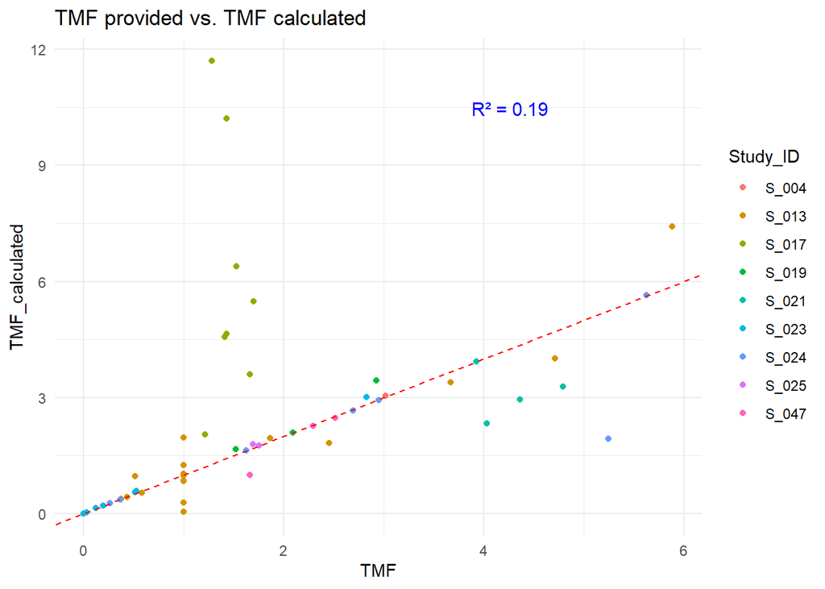

```r
# Create scatter plot with annotations and color by Study_ID
ggplot(data_draft, aes(x = TMF, y = TMF_calculated, color = Study_ID)) +
  geom_point() +
  geom_abline(slope = 1, intercept = 0, color = "red", linetype = "dashed") +
  labs(title = "TMF provided vs. TMF calculated",
       x = "TMF",
       y = "TMF_calculated") +
  theme_minimal() +
  annotate("text", x = Inf, y = Inf, label = paste("R² =", round(r_squared, 3)),
           hjust = 3, vjust = 5.5, size = 4, color = "blue")
```

As we can see from the above plot and the associated R-squared value, our TMFs and those reported in the literature do not quite match (R-squared = 0.19). However, the R-squared value increase drastically when removing S_017 (i.e., Liu et al., 2018) from the data set.

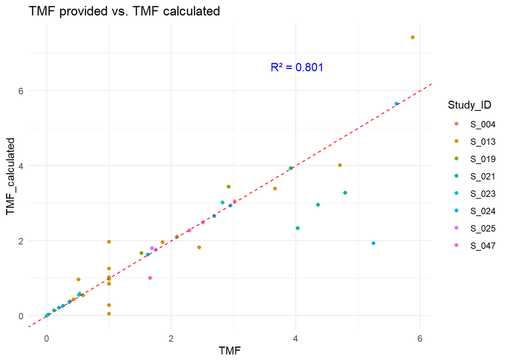

```r
data_draft2 <- data_draft %>%
  filter(Study_ID != "S_017")

model2 <- lm(TMF_calculated ~ TMF, data = data_draft2)
summary_model2 <- summary(model2)
r_squared2 <- summary_model2$r.squared

ggplot(data_draft2, aes(x = TMF, y = TMF_calculated, color = Study_ID)) +
  geom_point() +
  geom_abline(slope = 1, intercept = 0, color = "red", linetype = "dashed") +
  labs(title = "TMF provided vs. TMF calculated",
       x = "TMF",
       y = "TMF_calculated") +
  theme_minimal() +
  annotate("text", x = Inf, y = Inf, label = paste("R² =", round(r_squared2, 3)),
           hjust = 3, vjust = 5.5, size = 4, color = "blue")
```

# References

- Liu, W., He, W., Wu, J., Qin, N., He, Q., & Xu, F. (2018). Residues, bioaccumulations and biomagnification of perfluoroalkyl acids (PFAAs) in aquatic animals from Lake Chaohu, China. Environmental Pollution, 240, 607-614.